# Evolutionary rescue in flooding events

Ramin Dürst & Matthias Schönholzer

31.10.2024

## List of variables and parameters

### Already used in Prof. Banks code and adjusted to our model

- $N_a$ current size of the wild-type (a) population (changes over time)
- $N_A$ current size of the mutant (A) population (changes over time)
- `N_init_a` initial population size of wild-type population (should be a positive integer)
- `N_init_A` initial population size of the mutant population (should be a non-negative integer)
- `decay_rate` detrimental effect of the environment on the wild type (i.e. the growth rate, depending on which state the system is in. Positive decay_rate during event, negative decay_rate = growth rate while no event present)
- `sel_coeff` selection coefficient of wild type declines during the event, while the selection coefficient of the mutant increases during an event (sel_coeff higher in case of an event compared to sel_coeff during no event).
- `mut_rate` mutation rate from the wild type to the mutant genotype (should be 0> and small)
- `t_max` number of generations after which to stop the simulation (should be an integer >0; this is not a model parameter but a setting for the simulations). In the code presented here, the simulation stops automatically if the population goes extinct, or if it recovers and exceeds 1.5 times the original total population size, so `t_max` can be set to a large value without creating extremely long simulation times.

## Scenario / Biological question

A hypothetical population of plants in a water meadow by a river with two genotypes: one which does bad during flooding (wildtype) and one which does good during flooding (mutant). The frequency of being flooded increases due to climate change and depending on frequency, either the wildtype persists, the mutant takes over, or both genotypes and therefor the population go extinct.

How does the increasing frequency of flooding events affect the wildtype and mutant population of a water meadow, especially the population composition and the extinction rate of both genotypes?

### Hypothesis

- With low frequency of floods, the wildtype population has a higher chance to persist
- The higher the frequency of floods, the more likely the mutant can take over

## Generating the data

### Simulate one generation of population size change

We want to observe the numbers of wild-type and mutant individuals over time. As first step, we simulate one generation of the population. At time $t$, the population has $N_a$ wild-type individuals and $N_A$ mutant individuals. First, these reproduce. This is modeled by drawing a Poisson random variable according to the expected absolute number $N_a \cdot (1-r)$ of wild-type individuals, where $r$ is the decay rate of the wild type, and $N_A \cdot (1-r+s)$ of mutant individuals, where $s$ is the selective advantage of the mutant over the wild time. Then mutation from $a$ to $A$ occurs as a Poisson random variable according to the given mutation rate. This defines the composition of the population at time $t+1$.

```r
set.seed(1) # making it reproducible

simulate_one_gen <- function(N_a, N_A, decay_rate, sel_coeff, mut_rate) {
  # draw offspring according to Poisson distribution
  offsp_a <- rpois(1, N_a * (1-decay_rate))
  offsp_A <- rpois(1, N_A * (1-decay_rate+sel_coeff))
  # draw new mutants according to Poisson distribution
  mut_a_to_A <- rpois(1, offsp_a * mut_rate)

  # determine new population sizes of wild type and mutant
  N_a_new <- max(offsp_a - mut_a_to_A, 0)
  N_A_new <-  offsp_A + mut_a_to_A

  return(c(N_a_new, N_A_new))
}
# Test the function
print(simulate_one_gen(100,0,0.1,0.2,0.001))
```

```
## [1] 84  0
```

### Simulate a population trajectory

We can now track the dynamics of the population from one generation to another, but this is not enough. We want to follow the population from time 0 until it either is rescued or goes extinct. This is what the following function does.

```r
set.seed(2) # making it reproducible

simulate_pop <- function(N_init_a, N_init_A, decay_rate, sel_coeff, mut_rate, t_max) {
  # Create the vector in which to save the results
  pop_vector <- c(N_init_a, N_init_A)
  # initiate the variables
  pop_new <- c(N_init_a, N_init_A)

  # run the simulation until generation t_max
  for (i in 1:t_max+1) {
    # redefine the current population one generation later
    pop_new <- simulate_one_gen(pop_new[1],pop_new[2], decay_rate, sel_coeff, mut_rate)
    # add the new population sizes to the output vector
    pop_vector <- rbind(pop_vector,pop_new)
    # condition to stop the simulation before t_max: either the population exceeds 1.5 times the original population size, or it goes extinct
    if (pop_new[1]+pop_new[2]>=1.5*(N_init_a+ N_init_A) | pop_new[1]+pop_new[2]==0) break
  }

  # define the row and column names of the output vector
  rownames(pop_vector) <- (0:t_max)[1:length(pop_vector[,1])] # note that the vector has to be cut if the simulation stopped early
  colnames(pop_vector) <- c("Wildtype","Mutant")
  # return the result
  return(pop_vector)
}


# Test the function and plot the result
# set t_max to a value to be used throughout
max_gen <- 1000
# create your simulation data, with set mut_rate & sel_coeff
output <- simulate_pop(1000,0,0.1,0.2,0.001,max_gen)
# show the first and last few lines of the data table
print(head(output))
```

```
##   Wildtype Mutant
## 0     1000      0
## 1      873      0
## 2      830      0
## 3      772      1
## 4      698      2
## 5      622      1
```

```r
print(tail(output))
```

```
##    Wildtype Mutant
## 50        2    948
## 51        3   1030
## 52        3   1151
## 53        1   1230
## 54        1   1396
## 55        0   1554
```

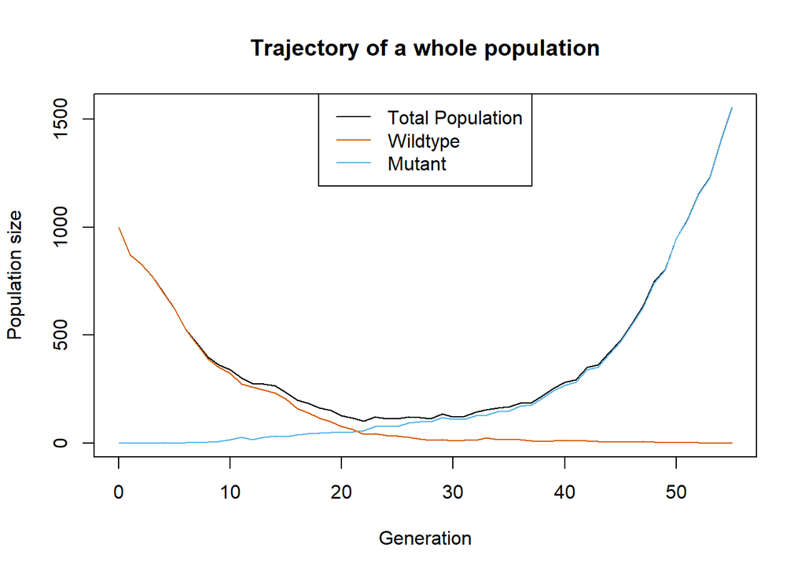

```r
# plot the output - note that the plot range and the x axis have to be adjusted based on the length of the table
# determine x axis range
x_range <- 0:(length(output[,1])-1)
# this plots the total population size
plot(x_range,output[,1]+output[,2],type='l',ylim=c(0,max(output[,1]+output[,2])),xlab = "Generation",ylab = "Population size", main = "Trajectory of a whole population")
# add number of wild type individuals
lines(x_range,output[,1], col="#D55E00")
# add number of mutant individuals
lines(x_range,output[,2], col="#56B4E9")
legend("top", legend = c("Total Population", "Wildtype", "Mutant"),
       col = c("#000000","#D55E00", "#56B4E9"),
       lty = 1)
```

### Simulating a whole population

Generate a population with the influence of events. Here we introduce and define the pause between events `t_pause` and the duration of the event `t_event`. Depending on in which state the system is (namely if the meadow is flooded or not) the decay-rate of the wildtype and the selection coefficient of the mutant vary. The function now calculates a whole population (with the function from above) with the addition a flood-event.

```r
set.seed(3) # making it reproducible

t_pause = 1 # time between floods with generations as unit (initial value: 1)
t_event = 5 # duration of the flood (initial value: 5)
t_switch = t_pause # giving t_switch a starting value


simulate_pop <- function(N_init_a, N_init_A, decay_rate, sel_coeff, mut_rate, t_max, t_pause) {
  # Create the vector in which to save the results
  pop_vector <- c(N_init_a, N_init_A)
  # initiate the variables
  pop_new <- c(N_init_a, N_init_A)

  ph = 0 # phase in the beginning of the simulation. Even numbers indicate no flood present, odd numbers indicate that a flood is present


  # run the simulation until generation t_max
  for (i in 1:t_max+1) {
    if(ph %%2 == 0){ # checking in which phase the system is. No flood is present initial values: decay_rate = -0.02 and sel_coeff = -0.015

    decay_rate = -0.02 # "growthrate" of wildtype when no flood is present
    sel_coeff = -0.015 # selection coeffictient of mutant when no flood is present

  }else{ # flood is present, initial values: decay_rate = 0.03 and sel_coeff = 0.05
    decay_rate = 0.03 # decayrate of wildtype if a flood is present
    sel_coeff = 0.05 # selection coefficient of mutant if a flood is present
  }

  if (i >= t_switch) { # changing the phase number, if the simulation is at the end of the phase
    if(ph %% 2 == 0) { # adding the duration of the flood after a period of no flood
      t_switch = t_switch + t_event
      ph = ph + 1
    }else{ # adding the duration of the pause between floods after a flood
      t_switch = t_switch + t_pause
      ph = ph + 1
    }
  }

    # redefine the current population one generation later
    pop_new <- simulate_one_gen(pop_new[1],pop_new[2], decay_rate, sel_coeff, mut_rate)
    # add the new population sizes to the output vector
    pop_vector <- rbind(pop_vector,pop_new)
    # condition to stop the simulation before t_max: either the population exceeds 1.5 times the original population size, or it goes extinct
    if (pop_new[1]+pop_new[2]>=1.5*(N_init_a+ N_init_A) | pop_new[1]+pop_new[2]==0) break
  }

  # define the row and column names of the output vector
  rownames(pop_vector) <- (0:t_max)[1:length(pop_vector[,1])] # note that the vector has to be cut if the simulation stopped early
  colnames(pop_vector) <- c("WT","Mut")
  # return the result
  return(pop_vector)
}

# Test the function and plot the result
# set t_max to a value to be used throughout, initial value: 1000
max_gen <- 1000
# create your simulation data
output <- simulate_pop(1000,0,0,0,0.001,max_gen, t_pause) #(initial values: 1000, 0, 0, 0.01, 0.001, max_gen, t_pause)
# show the last few lines of the data table
print(tail(output))
```

```
##     WT  Mut
## 307  0 1372
## 308  0 1356
## 309  0 1382
## 310  0 1397
## 311  0 1440
## 312  0 1507
```

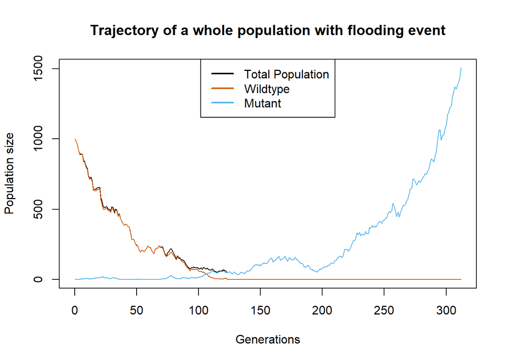

```r
# plot the output - note that the plot range and the x axis have to be adjusted based on the length of the table
# determine x axis range
x_range <- 0:(length(output[,1])-1)
# this plots the total population size
plot(x_range,output[,1]+output[,2],type='l',ylim=c(0,max(output[,1]+output[,2])),xlab = "Generations",ylab = "Population size", main = "Trajectory of a whole population with flooding event")
# add number of wild type individuals
lines(x_range,output[,1], col="#D55E00")
# add number of mutant individuals
lines(x_range,output[,2], col="#56B4E9")
legend("top", legend = c("Total Population", "Wildtype", "Mutant"),
       col = c("#000000","#D55E00", "#56B4E9"),
       lty = 1,
       lwd = 2)
```

### Generating multiple replicates at different frequencies and extracting the data

- `data_table_Pop`: frequency, final total population, final generation
- `data_table_Nw`: frequency, final population of wildtype, final generation
- `data_table_Nm`: frequency, final population of mutant, final generation
- `data_table_comp`: frequency, proportion of wildtype, proportion of mutant

While the first three data-tables give the final population of either the total, wildtype, or mutant and the corresponding generation depending on the frequency, the fourth data-table contains the proportions of wildtype and mutant depending on the frequency.

Additionally, we count the number of wildtype- and mutant-populations which survived after the set conditions and calculated the ratio of surviving.

```r
set.seed(4) # making it reproducible

# Set some parameters to fixed values
init_a <- 1000 # initial value: 1000
init_A <- 0 # initial value: 0
m_rate <- 0.001 # initial value: 0.001
max_gen <- 1000 # initial value: 1000
no_replicates <- 100 # initial value: 100

# Frequencies to vary
frequencies <- c(1:10) # initial value: c(1:10)

# Initialize data tables to collect results
data_table_Pop <- c() # Total population
data_table_Nw <- c() # Wildtype
data_table_Nm <- c() # Mutant
data_table_comp <- c() # Composition

# Initialize counters for survival
surviving_Nw <- numeric(length(frequencies))
surviving_Nm <- numeric(length(frequencies))

# Run the simulation across all chosen parameters
for (t_pause in frequencies) {
  i <- 1
  repeat {
    # Run the simulation once
    one_run <- simulate_pop(init_a, init_A, 0, 0, m_rate, max_gen, t_pause)

    # Determine the final sizes of the populations
    size_wt <- one_run[nrow(one_run), 1]
    size_mut <- one_run[nrow(one_run), 2]

    # Count surviving populations of wildtype and mutant
    if (size_wt > 0) {
      surviving_Nw[t_pause] <- surviving_Nw[t_pause] + 1
    }
    if (size_mut > 0) {
      surviving_Nm[t_pause] <- surviving_Nm[t_pause] + 1
    }

    # Enter the data into the tables
    final_size <- size_wt + size_mut
    final_gen <- nrow(one_run)

    data_table_Pop <- rbind(data_table_Pop, c(t_pause, final_size, final_gen))
    data_table_Nw <- rbind(data_table_Nw, c(t_pause, size_wt, final_gen))
    data_table_Nm <- rbind(data_table_Nm, c(t_pause, size_mut, final_gen))

    portion_WT <- size_wt / final_size
    portion_Mut <- size_mut / final_size

    data_table_comp <- rbind(data_table_comp, c(t_pause, portion_WT, portion_Mut))

    # Stop after the specified number of replicates
    if (i >= no_replicates) break
    i <- i + 1
  }
}

# Define column names of data tables
colnames(data_table_Pop) <- c("f", "Final Pop", "final_gen")
colnames(data_table_Nw) <- c("f", "Final WT", "final_gen")
colnames(data_table_Nm) <- c("f", "Final Mut", "final_gen")
colnames(data_table_comp) <- c("f", "Proportion_WT", "Proportion_Mut")

# Calculate ratios of surviving populations
ratios <- data.frame(
  t_pause = frequencies,
  Nw_survival_ratio = surviving_Nw / no_replicates,
  Nm_survival_ratio = surviving_Nm / no_replicates
)
```

## Plotting the data

### Survival-ratio of the wildtype

Here we plot the survival-ratio of the wildtype depending on the pause between events according to the data we got above. The higher the pause between events, the lower the frequency of events and vice versa. The graph shows that the less frequent events happen (the higher the pause between events is), the higher is the probability of survival.

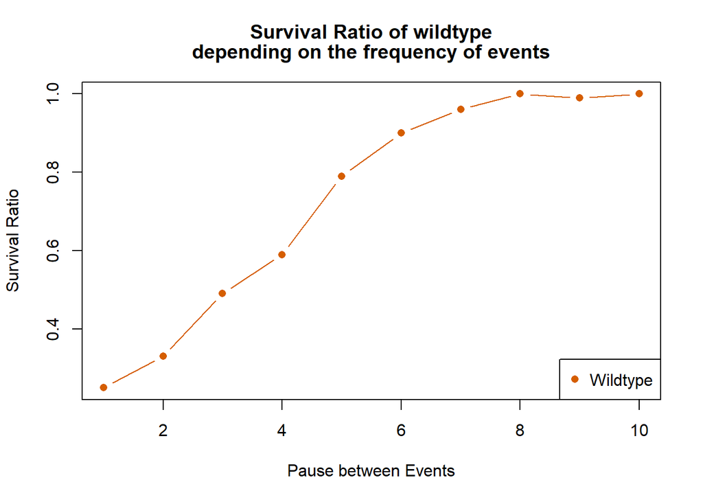

```r
set.seed(5) # making it reproducible

# Ensure ratios are numeric
ratios$t_pause <- as.numeric(as.character(ratios$t_pause))
ratios$Nw_survival_ratio <- as.numeric(as.character(ratios$Nw_survival_ratio))
ratios$Nm_survival_ratio <- as.numeric(as.character(ratios$Nm_survival_ratio))

# Plot for Wildtype survival ratio
plot(ratios$t_pause, ratios$Nw_survival_ratio,
     xlab = "Pause between Events",
     ylab = "Survival Ratio",
     main = c(paste("Survival Ratio of wildtype"), paste("depending on the frequency of events")),
     col = "#D55E00",
     type = "b",
     pch = c(16))  # Use a solid circle for points

# add a legend
legend("bottomright", legend = "Wildtype",
       col = "#D55E00",
       pch = 16)
```

### Mean proportion of wildtype and mutant according to the frequency

We want to show the composition of the population at different frequencies. In the first step, we create two data-tables with the frequencies and the corresponding average proportion of the mutant and the wildtype. The values are extracted from the `data_table_comp` created under “Generating multiple replicates at different frequencies and extracting the data”. With the two data-tables we create the stacked barplot with the composition of the population. The plot shows that populations at high frequencies (low pauses) contain mainly mutants, while a low frequency (high pauses) results in populations mainly compromised of wildtypes.

```r
set.seed(6) # making it reproducible

#creating two data-tables with frequency and corresponding proportion average of WT and MUT
mean_comp_WT <- aggregate(data_table_comp[,2]~ f, data = data_table_comp, FUN = mean)
mean_comp_Mut <- aggregate(data_table_comp[,3] ~ f, data = data_table_comp, FUN = mean)

options(warn = -1) # suppressing warnings of library (for neater Notebook)

# Load necessary libraries
library(tidyr)
library(dplyr)
```

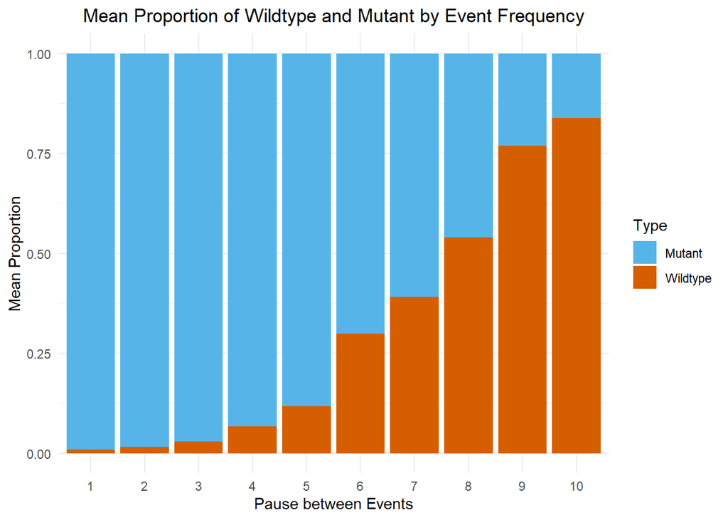

```r
library(ggplot2)

options(warn = 0) # setting warnings to default

# Combine the two data frames into one
# Ensure the names are consistent for merging
colnames(mean_comp_WT) <- c("f", "Proportion_WT")
colnames(mean_comp_Mut) <- c("f", "Proportion_Mut")

# Merge the data into one data-table
mean_comp <- merge(mean_comp_WT, mean_comp_Mut, by = "f")

# Reshape the data into long format for ggplot2
mean_comp_long <- mean_comp %>%
  pivot_longer(cols = c("Proportion_WT", "Proportion_Mut"),
               names_to = "Type",
               values_to = "Proportion")

# Plot the stacked bar chart
ggplot(mean_comp_long, aes(x = as.factor(f), y = Proportion, fill = Type)) +
  geom_bar(stat = "identity", position = "stack") +
  labs(x = "Pause between Events", # labeling x- and y-axis
       y = "Mean Proportion",
       title = "Mean Proportion of Wildtype and Mutant by Event Frequency") +
  scale_fill_manual(values = c("Proportion_WT" = "#D55E00", "Proportion_Mut" = "#56B4E9"), # applying correct colors
  labels = c("Mutant","Wildtype")) +
  theme_minimal() +
    theme(plot.title = element_text(hjust = 0.5))  # Center the title
```

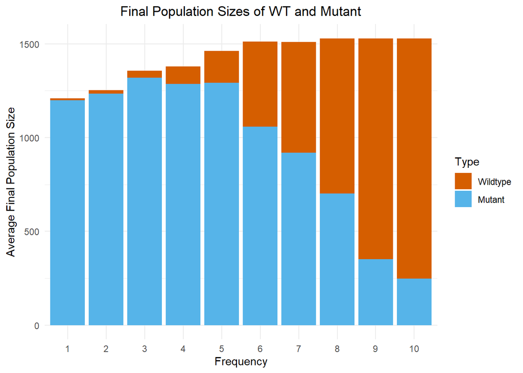

```r
set.seed(14)
# Load required packages
library(ggplot2)
library(reshape2)
# Initialize an empty data frame to store final results
final_numbers <- data.frame(
  f = frequencies,
  Final_WT = numeric(length(frequencies)),
  Final_Mut = numeric(length(frequencies))
)

# Loop through the frequencies and calculate the average final population sizes for WT and Mut
for (i in 1:length(frequencies)) {
  # Get the sizes for the current frequency (checking if the data is a matrix or data frame)
  if (is.data.frame(data_table_Nw)) {
    wt_size <- data_table_Nw[data_table_Nw$frequency == frequencies[i], "size"]
    mut_size <- data_table_Nm[data_table_Nm$frequency == frequencies[i], "size"]
  }
  else if (is.matrix(data_table_Nw)) {
    wt_size <- data_table_Nw[data_table_Nw[, 1] == frequencies[i], 2]
    mut_size <- data_table_Nm[data_table_Nm[, 1] == frequencies[i], 2]
  }

  # Calculate the average (mean) size including zeros
  final_numbers$Final_WT[i] <- ifelse(length(wt_size) > 0, mean(wt_size), 0)
  final_numbers$Final_Mut[i] <- ifelse(length(mut_size) > 0, mean(mut_size), 0)
}

# Melt the data frame to long format for plotting
melted_final_numbers <- melt(final_numbers, id.vars = "f",
                              measure.vars = c("Final_WT", "Final_Mut"))

# Create the stacked bar plot
ggplot(melted_final_numbers, aes(x = factor(f), y = value, fill = variable)) +
  geom_bar(stat = "identity", position = "stack") +
  labs(title = "Final Population Sizes of WT and Mutant",
       x = "Frequency",
       y = "Average Final Population Size",
       fill = "Type") +
  scale_fill_manual(values = c("Final_WT" = "#D55E00", "Final_Mut" = "#56B4E9"),
                    labels = c("Wildtype", "Mutant")) +
  theme_minimal() +
  theme(plot.title = element_text(hjust = 0.5))
```

### Exctinction rate depending on the frequency of events

Here we want to see, how the probability of the population going extinct changes with different frequencies of events. We extract the data for extinction from the large data table (`data_table_Pop`) by finding the ratio between the times the population went extinct and the total amount of replicates. This ratio is then visualized in a plot.

The plot shows that with increasing time between each event, the probability that the population goes extinct decreases.

```r
set.seed(7) # making it reproducible

# Ensure data_table_Pop is a data frame
data_table_Pop <- as.data.frame(data_table_Pop)

# Set column names
colnames(data_table_Pop) <- c("f", "Final_Pop", "final_gen")

# Initialize a vector to store extinction ratios for each frequency
extinction_ratios <- numeric(length(frequencies))

# Calculate extinction ratios for each frequency
for (t_pause in frequencies) {
  # Filter data for the current frequency
  current_data <- subset(data_table_Pop, f == t_pause)

  # Count how many populations went extinct (Final Pop == 0)
  extinct_count <- sum(current_data$Final_Pop == 0)

  # Calculate the extinction ratio (Number of extinct populations / number of replicates)
  extinction_ratios[t_pause] <- extinct_count / no_replicates
}

# Create a data frame for extinction ratios
extinction_df <- data.frame(
  t_pause = frequencies,
  extinction_ratio = extinction_ratios
)

# Print and view the extinction ratios
print(extinction_df)
```

```
##    t_pause extinction_ratio
## 1        1             0.21
## 2        2             0.18
## 3        3             0.11
## 4        4             0.10
## 5        5             0.04
## 6        6             0.01
## 7        7             0.01
## 8        8             0.00
## 9        9             0.00
## 10      10             0.00
```

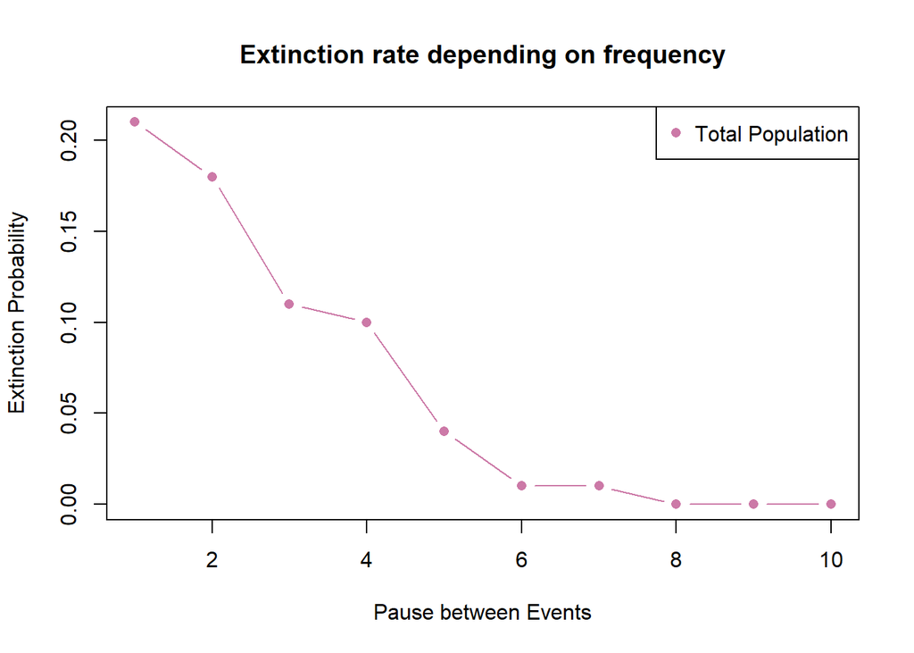

```r
plot(extinction_df[,1], extinction_df[,2],
     type = "b",
     pch = 16,
     col = "#CC79A7",
     ylab = "Extinction Probability",
     xlab = "Pause between Events",
     main = "Extinction rate depending on frequency")

legend("topright", legend = "Total Population",
       col = "#CC79A7",
       pch = 16)
```

The following plots show the extinction rate for the wildtype and the mutant separately. The code was copied from above and the names were adjusted accordingly.

```r
set.seed(8) # making it reproducible

# enabling plots to be in the same window
par(mfrow = c(1,2))

#data_table_Pop
# Ensure data_table_Pop is a data frame
data_table_Nw <- as.data.frame(data_table_Nw)

# Set column names (if not already set)
colnames(data_table_Nw) <- c("f", "Final_Pop", "final_gen")

# Initialize a vector to store extinction ratios for each frequency
extinction_ratios_WT <- numeric(length(frequencies))

# Calculate extinction ratios for each frequency
for (t_pause in frequencies) {
  # Filter data for the current frequency
  current_data_WT <- subset(data_table_Nw, f == t_pause)

  # Count how many populations went extinct (Final Pop == 0)
  extinct_count_WT <- sum(current_data_WT$Final_Pop == 0)

  # Calculate the extinction ratio (extinct_count / no_replicates)
  extinction_ratios_WT[t_pause] <- extinct_count_WT / no_replicates
}

# Create a data frame for extinction ratios
extinction_WT_df <- data.frame(
  t_pause = frequencies,
  extinction_ratio_WT = extinction_ratios_WT
)

# Print and view the extinction ratios
print(extinction_WT_df)
```

```
##    t_pause extinction_ratio_WT
## 1        1                0.75
## 2        2                0.67
## 3        3                0.51
## 4        4                0.41
## 5        5                0.21
## 6        6                0.10
## 7        7                0.04
## 8        8                0.00
## 9        9                0.01
## 10      10                0.00
```

```r
plot(extinction_WT_df[,1], extinction_WT_df[,2],
     type = "b",
     pch = 16,
     col = "#D55E00",
     ylab = "Extinction Probability WT",
     xlab = "Pause between Events",
     main = c(paste("WT-Extinction probability"), paste("depending on frequency")))

legend("topright", legend = "Wildtype",
       col = "#D55E00",
       pch = 16)

#data_table_Pop
# Ensure data_table_Pop is a data frame
data_table_Nm <- as.data.frame(data_table_Nm)

# Set column names (if not already set)
colnames(data_table_Nm) <- c("f", "Final_Pop", "final_gen")

# Initialize a vector to store extinction ratios for each frequency
extinction_ratios_MUT <- numeric(length(frequencies))

# Calculate extinction ratios for each frequency
for (t_pause in frequencies) {
  # Filter data for the current frequency
  current_data_MUT <- subset(data_table_Nm, f == t_pause)

  # Count how many populations went extinct (Final Pop == 0)
  extinct_count_MUT <- sum(current_data_MUT$Final_Pop == 0)

  # Calculate the extinction ratio (extinct_count / no_replicates)
  extinction_ratios_MUT[t_pause] <- extinct_count_MUT / no_replicates
}

# Create a data frame for extinction ratios
extinction_MUT_df <- data.frame(
  t_pause = frequencies,
  extinction_ratio_MUT = extinction_ratios_MUT
)

# Print and view the extinction ratios
print(extinction_MUT_df)
```

```
##    t_pause extinction_ratio_MUT
## 1        1                 0.21
## 2        2                 0.18
## 3        3                 0.11
## 4        4                 0.10
## 5        5                 0.04
## 6        6                 0.01
## 7        7                 0.01
## 8        8                 0.00
## 9        9                 0.00
## 10      10                 0.00
```

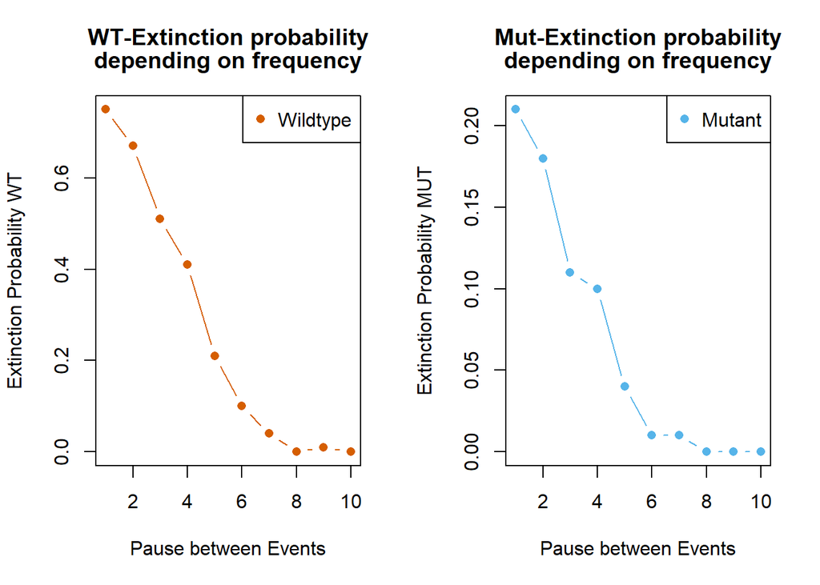

```r
plot(extinction_MUT_df[,1], extinction_MUT_df[,2],
     type = "b",
     pch = 16,
     col = "#56B4E9",
     ylab = "Extinction Probability MUT",
     xlab = "Pause between Events",
     main = c(paste("Mut-Extinction probability"), paste("depending on frequency")))

legend("topright", legend = "Mutant",
       col = "#56B4E9",
       pch = 16)
```

```r
# resetting window
par(mfrow= c(1,1))
```

### Distribution of final generations depending on the frequency (boxplot)

Here we want to see the relationship between the frequency of events and the final number of generations (the generation at which the simulation stopped. The conditions for the simulation to end were either extinction or the population growing to a size of 1.5 times the starting wildtype population.  
In this boxplot it can be seen, that the populations at medium frequencies ran for slightly longer. This can be explained with the following theories:

- Populations with very short or very long pauses either die out quickly or grow fast. At longer pauses between the events the mutation cannot fix and the wildtype then grows to a large population
- There is a aspect of stochasticity with the mutation rate
- There are to few events for the mutation to take over and to few for the wildtype to just grow without problems and therefore at the intermediate pauses the population struggles more to grow / decline to either stopping condition

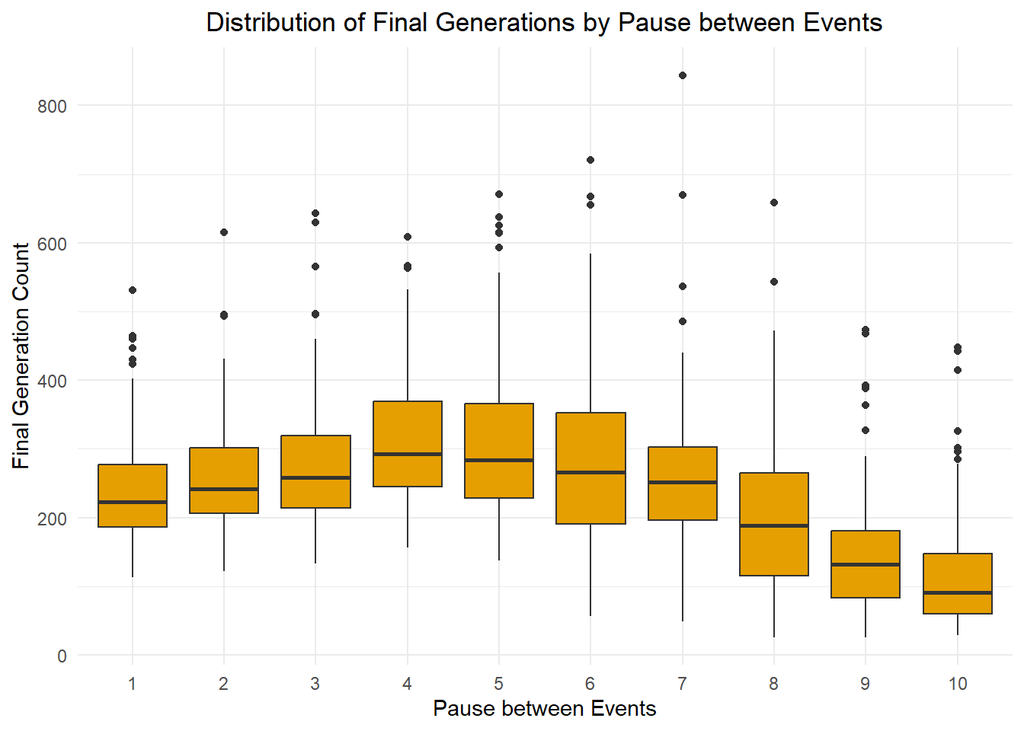

```r
set.seed(9) # making it reproducible

# generating a boxplot of the final generation and the frequency
ggplot(data_table_Pop, aes(x = as.factor(f), y = final_gen)) +
  geom_boxplot(fill = "#E69F00") +
  labs(x = "Pause between Events", y = "Final Generation Count",
       title = "Distribution of Final Generations by Pause between Events") +
  theme_minimal() +
  theme(plot.title = element_text(hjust = 0.5))  # Center the title
```

### Distribution of final generations depending on the frequency (Histogram)

Similar to the plot before, we want to visualize the relationship of the final generations and the frequencies of the events. The plot is not very clear, but it shows the same effect. On the higher end of generations are the populations with intermediate pauses (green-blueish color). Longer pauses show shorter simulation runs (pink color).

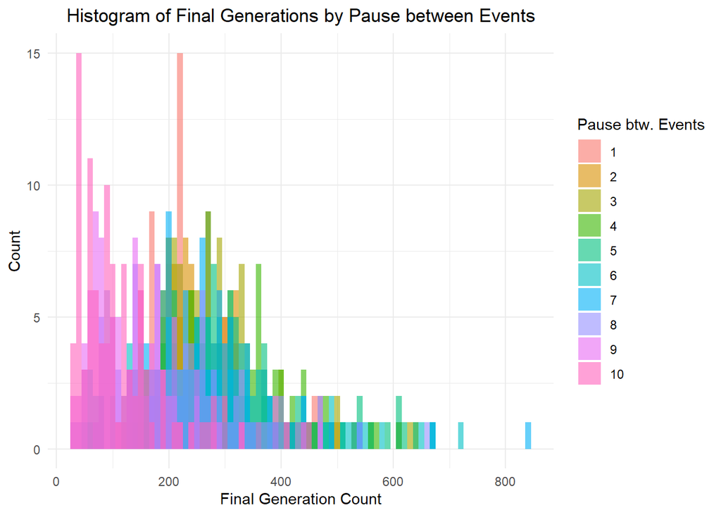

```r
set.seed(10) # making it reproducible

# generating a histogram of the final generation and the frequency
ggplot(data_table_Pop, aes(x = final_gen, fill = as.factor(f))) +
  geom_histogram(binwidth = 10, position = "identity", alpha = 0.6) +
  labs(x = "Final Generation Count", y = "Count",
       title = "Histogram of Final Generations by Pause between Events") +
  theme_minimal() +
  scale_fill_discrete(name = "Pause btw. Events") +
  theme(plot.title = element_text(hjust = 0.5))  # Center the title
```

### Extinction-generation across different frequencies

```r
set.seed(11) # making it reproducible

# Filter for populations that went extinct (Final_Pop == 0)
extinct_pop <- subset(data_table_Pop, Final_Pop == 0)

# Select only the frequency and generation of extinction
extinct_data <- extinct_pop[, c("f", "final_gen")]

# Optionally, rename columns for clarity
colnames(extinct_data) <- c("Frequency", "Extinction_Generation")

# View or print the resulting data
print(tail(extinct_data))
```

```
##     Frequency Extinction_Generation
## 438         5                   449
## 450         5                   671
## 488         5                   251
## 492         5                   366
## 541         6                   270
## 679         7                   293
```

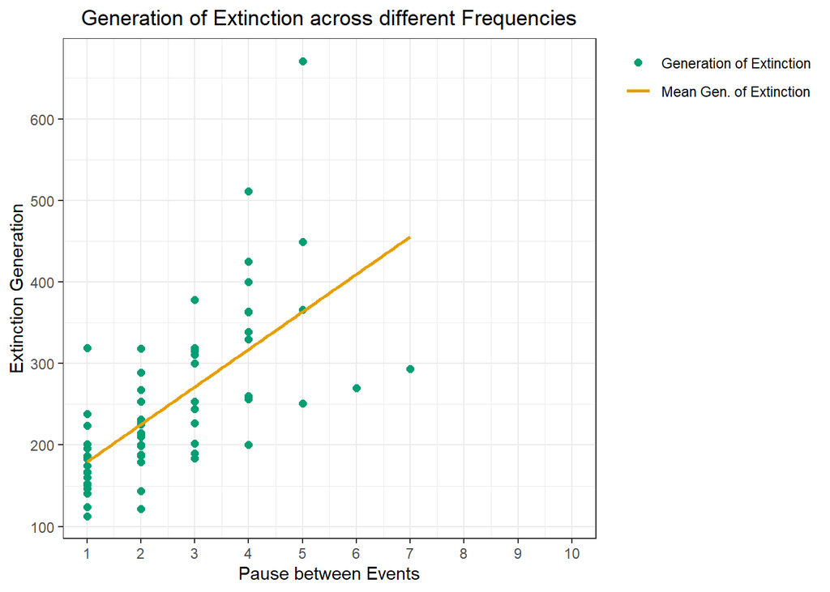

```r
#Plot the data
library(ggplot2)

# Example dataframe for context (replace with your actual data)
# extinct_data <- data.frame(Frequency = sample(1:10, 100, replace = TRUE),
#                             Extinction_Generation = sample(1:10, 100, replace = TRUE))

# Creating the plot with a legend
ggplot(extinct_data, aes(x = Frequency, y = Extinction_Generation)) +
  geom_point(aes(color = "Generation of Extinction"), pch = 16, size = 2) +  # Update legend label here
  geom_smooth(aes(color = "Mean Gen. of Extinction"), method = lm, se = FALSE) +  # Update legend label here
  labs(title = "Generation of Extinction across different Frequencies",
       x = "Pause between Events",
       y = "Extinction Generation") +
  theme_bw() +
  scale_color_manual(name = NULL, values = c("Generation of Extinction" = "#009E73",
                                                  "Mean Gen. of Extinction" = "#E69F00")) +  # Match the labels
  theme(
    legend.position.inside = c(.95, .95),
    legend.justification = c("right", "top"),
    legend.box.just = "right",
    legend.margin = margin(6, 6, 6, 6)
  ) +
  theme(plot.title = element_text(hjust = 0.5)) +  # Center the title
  scale_x_continuous(breaks = 1:10, limits = c(1, 10))  # Set x-axis to show only natural numbers 1 through 10
```

## Biological explanations

Our model simulates a simple scenario, where a plant population in a floodplain near a river experiences regular flooding events. The frequencies of these flooding increases due to climate change. The flooding of the plains is detrimental for the wildtype population, but there is a mutation which would be beneficial in case of flooding and benefits during the events. We want to simulate this scenario with different frequencies of events and see how the population changes. For this, we calculated and plotted multiple parameters and variables to show these relationships.

From our model we can deduce, that the frequency of flooding events has a large impact on the fate and composition of the population. With increasing frequency / shorter pauses between events, the mutation becomes more beneficial and can rescue the population. This evolutionary rescue is only possible, if at the timepoint at which the wildtype population goes extinct, the mutant is numerous enough to persist on its own. At lower frequencies / long pauses, the wildtype stays dominant in the population and persists. As long as wildtypes are present, a certain amount of mutants will also be present due to the fixed mutation rate.